Github site: https://github.com/ZhaiLab-SUSTech/flep_seq2_polya_analysis

# 1. File introduction

Files:

```
├── mRNA_median_length
│   ├── seedling.polya_length.txt
│   ├── seedling_rep1.polya_length.txt
│   ├── seedling_rep2.polya_length.txt
│   └── ...
├── orthofinder
│   ├── ath__v__maize.tsv
│   ├── ath__v__rice.tsv
│   ├── ath__v__soybean.tsv
│   ├── rice__v__maize.tsv
│   ├── soybean__v__maize.tsv
│   └── soybean__v__rice.tsv
├── alternative_spliced_isoform
│   ├── ath
│   │   ├── isoform.bed
│   │   ├── isoform.info.txt
│   │   └── isoform_polya_length_stat.txt
│   └── ...
├── bugv
├── genome_bed
│   ├── ath.bed
│   ├── maize.bed
│   ├── rice.bed
│   └── soybean.bed
├── read_info
│   ├── seedling_rep1.info.txt.gz
│   ├── seedling_rep2.info.txt.gz
│   └── ...
├── bam
│   ├── seedling_rep1.bam
│   ├── seedling_rep1.bam.bai
│   ├── seedling_rep2.bam
│   ├── seedling_rep2.bam.bai
│   └── ...
└── tmp_gene_bam
```

All files:

```
.
├── mRNA_median_length
│   ├── ath_nuc.polya_length.txt
│   ├── direct_rna.polya_length.txt
│   ├── flower.polya_length.txt
│   ├── inflorescence_rep1.polya_length.txt
│   ├── inflorescence_rep2.polya_length.txt
│   ├── leaf.polya_length.txt
│   ├── leaf_rep1.polya_length.txt
│   ├── leaf_rep2.polya_length.txt
│   ├── maize_nuc.polya_length.txt
│   ├── maize.polya_length.txt
│   ├── maize_rep1.polya_length.txt
│   ├── maize_rep2.polya_length.txt
│   ├── pacbio.seedling_rep1.polya_length.txt
│   ├── pacbio.seedling_rep2.polya_length.txt
│   ├── pollen.polya_length.txt
│   ├── pollen_rep1.polya_length.txt
│   ├── pollen_rep2.polya_length.txt
│   ├── rice_nuc.polya_length.txt
│   ├── rice.polya_length.txt
│   ├── rice_rep1.polya_length.txt
│   ├── rice_rep2.polya_length.txt
│   ├── root.polya_length.txt
│   ├── root_rep1.polya_length.txt
│   ├── root_rep2.polya_length.txt
│   ├── seedling.polya_length.txt
│   ├── seedling_rep1.polya_length.txt
│   ├── seedling_rep2.polya_length.txt
│   ├── seed.polya_length.txt
│   ├── seed_rep1.polya_length.txt
│   ├── seed_rep2.polya_length.txt
│   ├── shoot.polya_length.txt
│   ├── shoot_rep1.polya_length.txt
│   ├── shoot_rep2.polya_length.txt
│   ├── soybean_nuc.polya_length.txt
│   ├── soybean.polya_length.txt
│   ├── soybean_rep1.polya_length.txt
│   └── soybean_rep2.polya_length.txt
├── orthofinder
│   ├── ath__v__maize.tsv
│   ├── ath__v__rice.tsv
│   ├── ath__v__soybean.tsv
│   ├── rice__v__maize.tsv
│   ├── soybean__v__maize.tsv
│   └── soybean__v__rice.tsv
├── alternative_spliced_isoform
│   ├── ath
│   │   ├── isoform.bed
│   │   ├── isoform.info.txt
│   │   └── isoform_polya_length_stat.txt
│   ├── maize
│   │   ├── isoform.bed
│   │   ├── isoform.info.txt
│   │   └── isoform_polya_length_stat.txt
│   ├── rice
│   │   ├── isoform.bed
│   │   ├── isoform.info.txt
│   │   └── isoform_polya_length_stat.txt
│   └── soybean
│       ├── isoform.bed
│       ├── isoform.info.txt
│       └── isoform_polya_length_stat.txt
├── bugv #(not expend)
├── genome_bed
│   ├── ath.bed
│   ├── maize.bed
│   ├── rice.bed
│   └── soybean.bed
├── read_info
│   ├── ath_nuc.info.txt.gz
│   ├── direct_rna.info.txt.gz
│   ├── inflorescence_rep1.info.txt.gz
│   ├── inflorescence_rep2.info.txt.gz
│   ├── leaf_rep1.info.txt.gz
│   ├── leaf_rep2.info.txt.gz
│   ├── maize_nuc.info.txt.gz
│   ├── maize_rep1.info.txt.gz
│   ├── maize_rep2.info.txt.gz
│   ├── mh63.info.txt.gz
│   ├── pacbio.seedling_rep1.info.txt.gz
│   ├── pacbio.seedling_rep2.info.txt.gz
│   ├── pollen_rep1.info.txt.gz
│   ├── pollen_rep2.info.txt.gz
│   ├── rice_nuc.info.txt.gz
│   ├── rice_rep1.info.txt.gz
│   ├── rice_rep2.info.txt.gz
│   ├── root_rep1.info.txt.gz
│   ├── root_rep2.info.txt.gz
│   ├── seedling_rep1.info.txt.gz
│   ├── seedling_rep2.info.txt.gz
│   ├── seed_rep1.info.txt.gz
│   ├── seed_rep2.info.txt.gz
│   ├── shoot_rep1.info.txt.gz
│   ├── shoot_rep2.info.txt.gz
│   ├── soybean_nuc.info.txt.gz
│   ├── soybean_rep1.info.txt.gz
│   ├── soybean_rep2.info.txt.gz
│   └── zs97.info.txt.gz
├── bam
│   ├── ath_nuc.bam
│   ├── ath_nuc.bam.bai
│   ├── inflorescence_rep1.bam
│   ├── inflorescence_rep1.bam.bai
│   ├── inflorescence_rep2.bam
│   ├── inflorescence_rep2.bam.bai
│   ├── leaf_rep1.bam
│   ├── leaf_rep1.bam.bai
│   ├── leaf_rep2.bam
│   ├── leaf_rep2.bam.bai
│   ├── maize.bam
│   ├── maize.bam.bai
│   ├── maize_nuc.bam
│   ├── maize_nuc.bam.bai
│   ├── maize_rep1.bam
│   ├── maize_rep1.bam.bai
│   ├── maize_rep2.bam
│   ├── maize_rep2.bam.bai
│   ├── pacbio.seedling_rep1.bam
│   ├── pacbio.seedling_rep1.bam.bai
│   ├── pacbio.seedling_rep2.bam
│   ├── pacbio.seedling_rep2.bam.bai
│   ├── pollen_rep1.bam
│   ├── pollen_rep1.bam.bai
│   ├── pollen_rep2.bam
│   ├── pollen_rep2.bam.bai
│   ├── rice.bam
│   ├── rice.bam.bai
│   ├── rice_nuc.bam
│   ├── rice_nuc.bam.bai
│   ├── rice_rep1.bam
│   ├── rice_rep1.bam.bai
│   ├── rice_rep2.bam
│   ├── rice_rep2.bam.bai
│   ├── root_rep1.bam
│   ├── root_rep1.bam.bai
│   ├── root_rep2.bam
│   ├── root_rep2.bam.bai
│   ├── seedling.bam
│   ├── seedling.bam.bai
│   ├── seedling_rep1.bam
│   ├── seedling_rep1.bam.bai
│   ├── seedling_rep2.bam
│   ├── seedling_rep2.bam.bai
│   ├── seed_rep1.bam
│   ├── seed_rep1.bam.bai
│   ├── seed_rep2.bam
│   ├── seed_rep2.bam.bai
│   ├── shoot_rep1.bam
│   ├── shoot_rep1.bam.bai
│   ├── shoot_rep2.bam
│   ├── shoot_rep2.bam.bai
│   ├── soybean.bam
│   ├── soybean.bam.bai
│   ├── soybean_nuc.bam
│   ├── soybean_nuc.bam.bai
│   ├── soybean_rep1.bam
│   ├── soybean_rep1.bam.bai
│   ├── soybean_rep2.bam
│   ├── soybean_rep2.bam.bai
│   ├── upf1upf3.bam
│   ├── upf1upf3.bam.bai
│   ├── wt.bam
│   └── wt.bam.bai
└── tmp_gene_bam
    ├── AT3G01480.1.bam
    ├── AT3G01480.1.bam.bai
    ├── AT3G01480.ir.bam
    ├── AT3G01480.ir.bam.bai
    ├── AT3G01480.isoform2.bam
    └── AT3G01480.isoform2.bam.bai
```

## 1.1 In github

Download the files in the https://github.com/ZhaiLab-SUSTech/flep_seq2_polya_analysis , and unzip the tar file like:

```
tar -zxvf mRNA_median_length.tar.gz
tar -zxvf genome_bed.tar.gz
tar -zxvf orthofinder.tar.gz
tar -zxvf alternative_spliced_isoform.tar.gz
tar -zxvf tmp_gene_bam.tar.gz
```

### 1.1.1 mRNA_median_length

Include mRNA median length of each library, for example: `seedling_rep1.polya_length.txt`

```
├── mRNA_median_length
│   ├── seedling.polya_length.txt
│   ├── seedling_rep1.polya_length.txt
│   ├── seedling_rep2.polya_length.txt
```

```python
"""
Top five rows
Each row represent one gene.
All_*: all polyadenyated transcripts
ir_*: only full length (5' end start in or upstream the first exon,
        and  the 3' end end in or downstream the last exon) polyadenyated transcripts with unspliced introns
spliced_*: only full length fully-spliced polyadenyated transcripts
*n_read: read number
*median_polya: median polya tail length
*mean_polya: mean polya tail length
"""
import pandas as pd
test = pd.read_csv("mRNA_median_length/seedling_rep1.polya_length.txt", sep="\t")
test.head()
```

|  | mRNA | all_n_read | all_median_polya | all_mean_polya | ir_n_read | ir_median_polya | ir_mean_polya | spliced_n_read | spliced_median_polya | spliced_mean_polya |
| --- | --- | --- | --- | --- | --- | --- | --- | --- | --- | --- |
| 0 | AT1G01010.1 | 90 | 71.66 | 86.62 | 2 | 184.72 | 184.72 | 68 | 71.00 | 83.58 |
| 1 | AT1G01020.1 | 185 | 163.57 | 151.30 | 41 | 219.73 | 221.71 | 108 | 143.92 | 126.59 |
| 2 | AT1G01030.1 | 10 | 100.78 | 86.11 | 0 | 0.00 | 0.00 | 8 | 105.95 | 102.33 |
| 3 | AT1G01040.2 | 17 | 160.11 | 144.70 | 0 | 0.00 | 0.00 | 0 | 0.00 | 0.00 |
| 4 | AT1G01050.1 | 22 | 91.54 | 95.85 | 0 | 0.00 | 0.00 | 13 | 91.71 | 99.33 |

### 1.1.2 alternative_spliced_isoform

Used for plot Fig.2e in the paper.

```
├── alternative_spliced_isoform
│   ├── ath
│   │   ├── isoform.bed
│   │   ├── isoform.info.txt
│   │   └── isoform_polya_length_stat.txt
```

The information of alternative splcied isoforms.

#### 1.1.2.1 isoform.bed

See detail in https://genome.ucsc.edu/FAQ/FAQformat.html#format1.7

The fourth column is isoform name. It contain ".", such as AT1G01020.1, the string before "." is gene name (AT1G01020), the string after "." is used to distingush the isoforms of same gene.

```python
import pandas as pd
test = pd.read_csv("alternative_spliced_isoform/ath/isoform.bed", sep="\t", header=None)
test.head()
```

|  | 0 | 1 | 2 | 3 | 4 | 5 | 6 | 7 | 8 | 9 | 10 | 11 |
| --- | --- | --- | --- | --- | --- | --- | --- | --- | --- | --- | --- | --- |
| 0 | chr1 | 6787 | 9130 | AT1G01020.1 | 0 | - | 6914 | 8666 | 0 | 9 | 282,76,67,86,74,46,90,48,560, | 0,369,596,776,974,1154,1448,1629,1783, |
| 1 | chr1 | 6787 | 9130 | AT1G01020.isoform2 | 0 | - | 6835 | 8666 | 0 | 9 | 282,76,67,86,74,46,90,48,537, | 0,369,596,776,974,1154,1448,1629,1806, |
| 2 | chr1 | 99865 | 101987 | AT1G01240.1 | 0 | + | 100682 | 101678 | 0 | 2 | 166,1331, | 0,791, |
| 3 | chr1 | 99865 | 101987 | AT1G01240.2 | 0 | + | 100682 | 101678 | 0 | 2 | 355,1331, | 0,791, |
| 4 | chr1 | 387276 | 389808 | AT1G02090.1 | 0 | - | 387478 | 389568 | 0 | 9 | 227,89,139,71,45,90,89,76,399, | 0,307,991,1262,1439,1574,1773,1949,2133, |

#### 1.1.2.2 isoform.info.txt

Each row is an isoform. The isoform with isoform_index of 0 is major isoform.

The value in `select_intron_str` and `not_contain_intron_str` represent an intron (junction).

`8465-8570` means the intron start is 8465, and the intron end is 8570.

`select_intron_str`: the isoform contains the intron.

`not_contain_intron_str`: the isoform didn't contain the intron.

```python
import pandas as pd
test = pd.read_csv("alternative_spliced_isoform/ath/isoform.info.txt", sep="\t")
test.head()
```

|  | gene | isoform_index | isoform_name | select_intron_str | not_contain_intron_str | annoted_represent_mRNA |
| --- | --- | --- | --- | --- | --- | --- |
| 0 | AT1G01020 | 0 | AT1G01020.1 | 8465-8570 | 8465-8593 | AT1G01020.1 |
| 1 | AT1G01020 | 1 | AT1G01020.isoform2 | 8465-8593 | 8465-8570 | AT1G01020.1 |
| 2 | AT1G01240 | 0 | AT1G01240.1 | 100032-100656 | 100221-100656 | AT1G01240.1 |
| 3 | AT1G01240 | 1 | AT1G01240.2 | 100221-100656 | 100032-100656 | AT1G01240.1 |
| 4 | AT1G02090 | 0 | AT1G02090.1 | 387673-388267 | 387656-388267 | AT1G02090.1 |

#### 1.1.2.3 isoform_polya_length_stat.txt

The read count and polya_length of major and minor isoforms.

`minor_isoform_index` is the isoform_index of minor isoforms (stored in `isoform.info.txt`)

The isoform_index of major isoform is 0, thus the file don't store `major_isoform_index`.

*sample1*: data from replicate 1 *sample2*: data from replicate 2

`major_median_polya_length`, `minor_median_polya_length`: the median polya length of major and minor isoforms.

The differentially analysis of polya tail length between major and minor isoforms:

`padj`: the adjusted p values.

`diff`: 0: not differential. 1: minor longer. 2: major longer.

```python
import pandas as pd
test = pd.read_csv("alternative_spliced_isoform/ath/isoform_polya_length_stat.txt", sep="\t")
test.head()
```

|  | gene_name | minor_isoform_index | major_count | major_sample1_count | major_sample2_count | minor_count | minor_sample1_count | minor_sample2_count | major_median_polya_length | major_sample1_median_polya_length | ... | minor_sample2_median_polya_length | major_mean_polya_length | major_sample1_mean_polya_length | major_sample2_mean_polya_length | minor_mean_polya_length | minor_sample1_mean_polya_length | minor_sample2_mean_polya_length | pvalue | padj | diff |
| --- | --- | --- | --- | --- | --- | --- | --- | --- | --- | --- | --- | --- | --- | --- | --- | --- | --- | --- | --- | --- | --- |
| 0 | AT1G01020 | 1 | 243 | 108 | 135 | 95 | 39 | 56 | 169.119995 | 155.820000 | ... | 197.369995 | 150.465185 | 139.333796 | 159.370296 | 179.463368 | 167.801026 | 187.585356 | 1.662318e-03 | 6.513881e-03 | 0.0 |
| 1 | AT1G01240 | 1 | 413 | 195 | 218 | 69 | 32 | 37 | 80.559998 | 79.510002 | ... | 112.209999 | 84.172518 | 85.544616 | 82.945184 | 109.071304 | 110.597188 | 107.751621 | 4.586873e-04 | 2.006178e-03 | 1.0 |
| 2 | AT1G02090 | 1 | 125 | 57 | 68 | 21 | 10 | 11 | 93.930000 | 93.930000 | ... | 118.239998 | 100.649680 | 94.593860 | 105.725883 | 116.458095 | 111.468001 | 120.994545 | 7.048142e-02 | 1.650136e-01 | 0.0 |
| 3 | AT1G02560 | 1 | 656 | 314 | 342 | 28 | 13 | 15 | 97.544998 | 89.225002 | ... | 82.489998 | 95.511143 | 91.532389 | 99.164152 | 88.481785 | 90.517692 | 86.717332 | 2.494276e-01 | 3.642569e-01 | 0.0 |
| 4 | AT1G02840 | 1 | 516 | 257 | 259 | 89 | 44 | 45 | 67.095001 | 66.529999 | ... | 247.470001 | 83.329458 | 84.371946 | 82.295020 | 241.208989 | 235.165001 | 247.118667 | 2.042683e-40 | 2.948272e-38 | 1.0 |

5 rows × 23 columns

### 1.1.3 genome_bed

See detail in https://genome.ucsc.edu/FAQ/FAQformat.html#format1.7.

The used genome and annotation versions of Arabidopsis, soybean, rice, maize were ARAPROT11 (https://www.arabidopsis.org/), Wm82.gnm4.ann1.T8TQ (https://soybase.org/), MSU7 (http://rice.uga.edu), B73 RefGen_v5 (https://maizegdb.org), respectively.

```
├── genome_bed
│   ├── ath.bed
│   ├── maize.bed
│   ├── rice.bed
│   └── soybean.bed
```

```python
import pandas as pd
test = pd.read_csv("genome_bed/ath.bed", sep="\t", header=None)
test.head()
```

|  | 0 | 1 | 2 | 3 | 4 | 5 | 6 | 7 | 8 | 9 | 10 | 11 |
| --- | --- | --- | --- | --- | --- | --- | --- | --- | --- | --- | --- | --- |
| 0 | chr1 | 3630 | 5899 | AT1G01010.1 | 0 | + | 3759 | 5630 | 0 | 6 | 283,281,120,390,153,461, | 0,365,855,1075,1543,1808, |
| 1 | chr1 | 6787 | 9130 | AT1G01020.1 | 0 | - | 6914 | 8666 | 0 | 9 | 282,76,67,86,74,46,90,48,560, | 0,369,596,776,974,1154,1448,1629,1783, |
| 2 | chr1 | 11648 | 13714 | AT1G01030.1 | 0 | - | 11863 | 12940 | 0 | 2 | 1525,380, | 0,1686, |
| 3 | chr1 | 23415 | 31120 | AT1G01040.2 | 0 | + | 23518 | 31079 | 0 | 20 | 1036,114,211,395,220,173,123,161,234,151,183,1... | 0,1126,1336,1625,2108,2409,2665,2876,3127,3446... |
| 4 | chr1 | 31169 | 33171 | AT1G01050.1 | 0 | - | 31381 | 32670 | 0 | 9 | 255,82,121,66,108,66,29,124,143, | 0,351,523,763,918,1112,1261,1377,1859, |

### 1.1.4 orthofinder

To identify orthologs among different species, the protein sequences of all four species were exported to OrthoFinder software with default parameters.

The files are the output of OrthoFinder software.

```
├── orthofinder
│   ├── ath__v__maize.tsv
│   ├── ath__v__rice.tsv
│   ├── ath__v__soybean.tsv
│   ├── rice__v__maize.tsv
│   ├── soybean__v__maize.tsv
│   └── soybean__v__rice.tsv
```

```python
import pandas as pd
test = pd.read_csv("orthofinder/ath__v__maize.tsv", sep="\t")
test.head()
```

|  | Orthogroup | ath | maize |
| --- | --- | --- | --- |
| 0 | OG0000101 | AT3G60330.1 | Zm00001eb000210.1 |
| 1 | OG0000101 | AT3G47950.1, AT5G62670.1 | Zm00001eb053440.1, Zm00001eb134090.1, Zm00001e... |
| 2 | OG0000101 | AT2G07560.1, AT3G42640.1 | Zm00001eb275100.2, Zm00001eb386740.1 |
| 3 | OG0000101 | AT2G24520.2 | Zm00001eb067750.1, Zm00001eb432500.1 |
| 4 | OG0000102 | AT1G10360.1, AT1G10370.1 | Zm00001eb173570.1, Zm00001eb021690.1, Zm00001e... |

### 1.1.5 tmp_gene_bam

Temporary bam files generated from original bam files.

Bam is alignment file of seqeuncing reads. See detail in https://github.com/samtools/hts-specs.

```
── tmp_gene_bam
    ├── AT3G01480.1.bam
    ├── AT3G01480.1.bam.bai
    ├── AT3G01480.ir.bam
    ├── AT3G01480.ir.bam.bai
    ├── AT3G01480.isoform2.bam
    └── AT3G01480.isoform2.bam.bai
```

## 1.2 In China National Center for Bioinformation with accession OMIX881

### 1.2.1 read information

Download read_info.tar and unzip them by `tar -xvf read_info.tar`.

```
├── read_info
│   ├── ath_nuc.info.txt.gz
│   ├── direct_rna.info.txt.gz
│   ├── inflorescence_rep1.info.txt.gz
│   ├── inflorescence_rep2.info.txt.gz
│   ├── leaf_rep1.info.txt.gz
│   ├── leaf_rep2.info.txt.gz
│   ├── maize_nuc.info.txt.gz
```

Unzip each file using gunzip: `gunzip -c seedling_rep1.info.txt.gz > seedling_rep1.info.txt`.

Each file is the information of all reads in one FLEP-seq2 library.

The file is a simple version of read info file described in https://github.com/ZhaiLab-SUSTech/FLEPSeq.

It is generate by extract_read_info.py and PolyACaller.py in https://github.com/ZhaiLab-SUSTech/FLEPSeq

The columns:

```
read_core_id            de4d183f-9187-43e5-ab03-56ce63e7de88,chr1,7030,8176
mRNA                    AT1G01020.1  #mRNA name
mRNA_length             2343
mRNA_intron_num         8            #total intron number of mRNA
rel_mRNA_pos5           954          #the 5' end position of read relative to the 5' end of mRNA (0-based)
rel_mRNA_pos3           -242         #the 3' end poistion of read relative to the 3' end of mRNA (0-based)
f_feature_type          intron
f_feature_num           3
l_feature_type          exon
l_feature_num           9
retention_introns       3:4:6        #retained intron, seprated by ":", the intron number is ordered from 5' mRNA to 3' mRNA
type                    elongating
polya_length            83.34
```

1. read_core_id

Due to that one read may be mapped to multiple positions, we merge read id and mapping information to represent each alignment:

```
read_id:      7fab6cbf-a9ed-4427-951f-741515ddba0b
read_core_id: 7fab6cbf-a9ed-4427-951f-741515ddba0b,chr1,7026,8687
```

1. rel_mRNA_pos5, and rel_mRNA_pos3

```
gene (length: l)  ----->>>>>>>>>>>>>>>>>>>>>>---------      >>>> repesent gene
                  |    |   |              | |    |
                 -4    0   4             -2 0    5
                  (rel_mRNA_pos5)            (rel_mRNA_pos3)

    gene          -----<<<<<<<<<<<<<<<<<<<<<<---------
                       |                    |
                  (rel_mRNA_pos3)      (rel_mRNA_pos5)
```

```
 >>>> exon,  .... intron
mRNA            >>>>>>>>>>>.......>>>>>>>>>
read          >>>>>>>>>>>>>.......>>>>>>>>>>>>
              |                              |
              |                              |
              |                              |
          rel_mRNA_pos5                 rel_mRNA_pos3
```

1. f_feature, l_feature

```
                  exon1        intron1          exon2        intron2       exon3
mRNA           >>>>>>>>>>>>...............>>>>>>>>>>>>>>>...............>>>>>>>>>>>
read                >>>>>>>...............>>>>>>>>>>>>>>>>>>>>>>>
```

f_feature: the 5' end feature overlapping with this read, in this example, it is the first exon: exon1, thus `f_feature_type` is "exon", `f_feature_num` is 1, it is the first read exon of the read overlapping with it, thus `f_read_exon_num` is 1. f_pos5 and f_pos3 is the position of the read exon 1 relative the exon1, the value is like mRNA_pos5 and mRNA_pos3.

l_feature: the 3' end feature overlapping with this read, in this example, it is the second intron: intron2, thus `l_feature_type` is "intron", `l_feature_num` is 2, it is the second read exon of the read overlapping with it, thus `l_read_exon_num` is 2.

1. intron retention

for each intron overlapping with this read:

(a) if it is the f_feature: it would be retented. but this may be affected by 3' SS.

(b) if it is the l_feature: the transcription hasn't been finished. not retented.

(c) in the inner: if coverage_ratio >= 0.8: retention.

1. type

polyadenylated transcripts: (polya_length >= 10)

`polya`: `end_type` is 3.

`polya_5lost`: `end_type` is 0 or 2

`polya_3_not_in_last_exon`: `end_type` is 1

not polyadenylated transcripts:

`elongating`

`elongating_5lost`

`elongating_3_mapping_low_accuracy`

`splicing_intermediate`

end_type:

```
mRNA                >>>>>>>>>>>.......>>>>>>>>>.........>>>>>>>>>>
read  end_type: 0                  >>>>>>>>>>>>>>>
      end_type: 1     >>>>>>>>>>>>>>>>>>>>>>
      end_type: 2                  >>>>>>>>>>>>>>>>>>>>>>>>>>>>>>
      end_type: 3   >>>>>>>>>>>>>>>>>>>>>>>>>>>>>>>>>>>>>>>>>>>>>

    #end5: read overlapped with the the first exon
    #end3: read overlapped with the the last exon
    #         noend5 end5
    #noend3      0    1
    #end3        2    3
```

See detail in https://github.com/ZhaiLab-SUSTech/FLEPSeq.

```python
import pandas as pd
test = pd.read_csv("read_info/seedling_rep1.info.txt", sep="\t")
test.head()
```

|  | read_core_id | mRNA | mRNA_length | mRNA_intron_num | rel_mRNA_pos3 | rel_mRNA_pos5 | f_feature_type | f_feature_num | l_feature_type | l_feature_num | retention_introns | type | polya_length |
| --- | --- | --- | --- | --- | --- | --- | --- | --- | --- | --- | --- | --- | --- |
| 0 | befd035a-f9e7-4568-ae12-f310c6daf13a,chr1,3614... | AT1G01010.1 | 2269 | 5 | 25 | -17 | exon | 1 | exon | 6 | NaN | polya | 57.91 |
| 1 | 959c84fb-b55c-4ec5-ac2c-a981ca60c94f,chr1,3617... | AT1G01010.1 | 2269 | 5 | -52 | -14 | exon | 1 | exon | 6 | NaN | polya | 36.36 |
| 2 | 0495f54c-bc7d-4fbb-9ff0-4e3305cf4dff,chr1,3617... | AT1G01010.1 | 2269 | 5 | -2009 | -14 | exon | 1 | exon | 1 | NaN | elongating_3_mapping_low_accuracy | 1.74 |
| 3 | d11aab7b-9ecd-461a-8532-e3c48864c89b,chr1,3627... | AT1G01010.1 | 2269 | 5 | 3 | -4 | exon | 1 | exon | 6 | NaN | polya | 26.45 |
| 4 | 550afe87-d027-4d55-a1fb-2d0969bfd99c,chr1,3629... | AT1G01010.1 | 2269 | 5 | -52 | -2 | exon | 1 | exon | 6 | NaN | polya | 38.66 |

### 1.2.2 bam

Bam is alignment file of seqeuncing reads. See detail in https://github.com/samtools/hts-specs.

Download all bam files.

Download `bai.tar.gz` and unzip it by `tar -zxvf bai.tar.gz`. These files are the index files of bam files.

Creat `bam` directory by `mkdir bam`.

Put all bam files and bai files in the `bam` directory.

```
├── bam
│   ├── ath_nuc.bam
│   ├── ath_nuc.bam.bai
│   ├── inflorescence_rep1.bam
│   ├── inflorescence_rep1.bam.bai
│   ├── inflorescence_rep2.bam
│   ├── inflorescence_rep2.bam.bai
```

The bam also stroes these tags (values from read_info.txt):

```
tag_name tag_type tag_meaning
ty       Z        read_type
mi       Z        mRNA name
rs       Z        rna_strand
ir       Z        retention_intron
pa       f        polya_length
```

# 2. import

Python 3.7.4

```python
import os
import typing
import matplotlib as mpl
import matplotlib.pyplot as plt
import numpy as np
import pandas as pd
import seaborn as sns
import collections
import math
import scipy.stats
from scipy.stats import gaussian_kde, variation
from scipy.stats import pearsonr
import sys
```

```python
%matplotlib inline
```

```python
%config InlineBackend.figure_format = 'retina'
```

```python
default_pal = sns.color_palette()
```

# 3. Read data

```python
samples = ['inflorescence_rep1', 'inflorescence_rep2',
           'root_rep1', 'root_rep2',
           'seed_rep1', 'seed_rep2',
           'seedling_rep1', 'seedling_rep2',
           'shoot_rep1', 'shoot_rep2',
           'leaf_rep1', 'leaf_rep2',
           'pollen_rep1', 'pollen_rep2',
           'soybean_rep1', 'soybean_rep2',
           'maize_rep1', 'maize_rep2',
           'rice_rep1', 'rice_rep2',
           'maize_nuc',
           'rice_nuc',
           'soybean_nuc',
           'ath_nuc',
           'direct_rna']

groups = ["flower", "root", "seed", "leaf",
          "shoot", "seedling", "pollen",
          "soybean", "maize", "rice"]
```

```python
data_dir = "./"
```

```python
read_info_dir = os.path.join(data_dir, "read_info")
```

```python
homologous_data_dir = os.path.join(data_dir, "orthofinder")
```

```python
mRNA_median_length_dir = os.path.join(data_dir, "mRNA_median_length")
```

```python
origin_bam_dir = os.path.join(data_dir, "bam")
tmp_gene_bam_dir = os.path.join(data_dir, "tmp_gene_bam")
```

## 3.1 read info

```python
def read_info(sample):
    #require read_info_dir
    filein = os.path.join(read_info_dir, f"{sample}.info.txt")
    data = pd.read_csv(filein,
                       sep="\t",
                       dtype={"retention_introns": str})
    data.retention_introns.fillna("", inplace=True)
    return data
```

```python
def read_info_ftr(sample):
    #require read_info_dir
    fileout = os.path.join(read_info_dir, f"{sample}.info.ftr")
    data = pd.read_feather(fileout)
    return data
```

Read read info to Data Frame using the sample name.

```python
seedling_rep1 = read_info("seedling_rep1")
```

```python
seedling_rep2 = read_info("seedling_rep2")
```

```python
leaf_rep1 = read_info("leaf_rep1")
```

```python
leaf_rep2 = read_info("leaf_rep2")
```

```python
ath_nuc = read_info("ath_nuc")
```

Option: You can write the Data Frame to feather file, and then you can read feather to load this Data Frame, which is faster.

```python
sample = "seedling_rep1"
fileout = os.path.join(read_info_dir, f"{sample}.info.ftr")
#write
seedling_rep1.to_feather(fileout)
```

```python
#load
seedling_rep1 = read_info_ftr("seedling_rep1")
```

## 3.2 (Option) Calculate median poly(A) length of genes

```python
def stat_polya_length(df, columns=("mRNA", "n_read", "median_polya", "mean_polya")):
    stat_results = (df.groupby('mRNA')["polya_length"].
                      agg([len, np.median, np.mean]).
                      reset_index())
    if columns:
        stat_results.columns = columns
    return stat_results
```

```python
def stat_all_ir_spliced_polya_length(df):
    df = df.query('polya_length >= 10')
    all_polya_length = stat_polya_length(df, ["mRNA", "all_n_read", "all_median_polya", "all_mean_polya"])

    df_full_length = df.query('type == "polya"')
    df_ir = df_full_length.query('retention_introns != ""')
    df_spliced = df_full_length.query('retention_introns == ""')

    ir_polya_length = stat_polya_length(df_ir,
                                        ["mRNA", "ir_n_read", "ir_median_polya", "ir_mean_polya"])

    spliced_polya_length = stat_polya_length(df_spliced,
                                        ["mRNA", "spliced_n_read", "spliced_median_polya", "spliced_mean_polya"])

    mRNA_polya_length = (all_polya_length.
                            merge(ir_polya_length, on="mRNA", how="left").
                            merge(spliced_polya_length, on="mRNA", how="left"))

    mRNA_polya_length.fillna(0, inplace=True)

    for column in ["all_n_read", "ir_n_read", "spliced_n_read"]:
        mRNA_polya_length[column] = mRNA_polya_length[column].astype(int)

    return mRNA_polya_length
```

```python
seedling_rep1_polya_length = stat_all_ir_spliced_polya_length(seedling_rep1)
```

```python
seedling_rep2_polya_length = stat_all_ir_spliced_polya_length(seedling_rep2)
```

```python
ath_nuc_polya_length = stat_all_ir_spliced_polya_length(ath_nuc)
```

```python
seedling_polya_length = stat_all_ir_spliced_polya_length(pd.concat([seedling_rep1, seedling_rep2]))
```

```python
seedling_rep1_polya_length
```

|  | mRNA | all_n_read | all_median_polya | all_mean_polya | ir_n_read | ir_median_polya | ir_mean_polya | spliced_n_read | spliced_median_polya | spliced_mean_polya |
| --- | --- | --- | --- | --- | --- | --- | --- | --- | --- | --- |
| 0 | AT1G01010.1 | 90 | 71.665 | 86.615222 | 2 | 184.720 | 184.720000 | 68 | 71.005 | 83.584706 |
| 1 | AT1G01020.1 | 185 | 163.570 | 151.295946 | 41 | 219.730 | 221.713415 | 108 | 143.920 | 126.593889 |
| 2 | AT1G01030.1 | 10 | 100.780 | 86.113000 | 0 | 0.000 | 0.000000 | 8 | 105.950 | 102.328750 |
| 3 | AT1G01040.2 | 17 | 160.110 | 144.695294 | 0 | 0.000 | 0.000000 | 0 | 0.000 | 0.000000 |
| 4 | AT1G01050.1 | 22 | 91.540 | 95.845000 | 0 | 0.000 | 0.000000 | 13 | 91.710 | 99.326923 |
| ... | ... | ... | ... | ... | ... | ... | ... | ... | ... | ... |
| 20985 | AT5G67600.1 | 705 | 73.390 | 80.892482 | 5 | 167.270 | 156.012000 | 669 | 72.690 | 79.936457 |
| 20986 | AT5G67610.2 | 67 | 145.270 | 139.103582 | 11 | 198.880 | 196.394545 | 38 | 140.025 | 124.522895 |
| 20987 | AT5G67620.1 | 28 | 112.650 | 98.608571 | 0 | 0.000 | 0.000000 | 26 | 112.650 | 96.850769 |
| 20988 | AT5G67630.1 | 43 | 59.680 | 69.007209 | 0 | 0.000 | 0.000000 | 31 | 59.680 | 72.743548 |
| 20989 | AT5G67640.1 | 57 | 87.770 | 92.300351 | 2 | 225.915 | 225.915000 | 47 | 75.750 | 82.533191 |

20990 rows × 10 columns

# 4. Fig 1 Plot length distriubtion

## 4.1 Plot hist read length distriubtion

Flep-seq2 can capture both the transcripts with and without poly(A) tails.

We used min_polya_length of 10 to chose poly(A) reads.

```python
def plot_hist_samples_polya_length(xs,
                                   samples,
                                   bin_length=1,
                                   min_length=10,
                                   max_length = 300,
                                   figsize=None,
                                   linewidth=2,
                                   linestyle=None,
                                   color=None,
                                   plot_legend=True,
                                   ax=None,
                                   xlab="Poly(A) tail length",
                                   ylab="Ratio of Reads"):

    if ax is None:
        fig, ax = plt.subplots(figsize=figsize)

    for sample, x in zip(samples, xs):
        x = x[(x >= min_length) & (x <= max_length)]
        w = np.ones(len(x)) / x.sum()
        ax.hist(
            x,
            bins = np.arange(min_length, max_length, bin_length),
            weights=w,
            histtype="step",
            label=sample,
            density=True,
            linewidth=linewidth,
            linestyle=linestyle,
            color=color
        )

    ax.set_ylim(0)
    ax.set_xlim(None, max_length)

    ax.set_xlabel(xlab)
    ax.set_ylabel(ylab)
    if plot_legend:
        plt.legend(bbox_to_anchor=[1, 0.5])
```

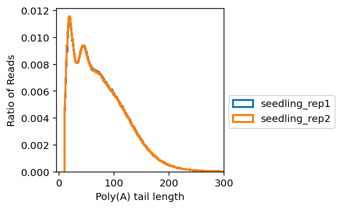

```python
plot_hist_samples_polya_length(xs = [seedling_rep1.polya_length, seedling_rep2.polya_length],
                              samples = ["seedling_rep1", "seedling_rep2"],
                              figsize = [3, 3],
                              plot_legend = True)
```

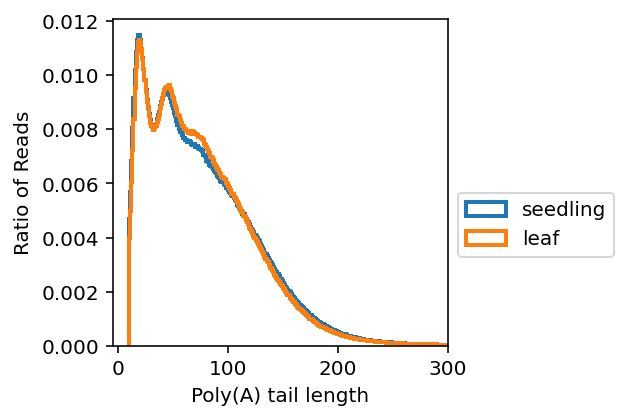

```python
plot_hist_samples_polya_length(xs = [np.concatenate([seedling_rep1.polya_length, seedling_rep2.polya_length]),
                                     np.concatenate([leaf_rep1.polya_length, leaf_rep2.polya_length])],
                              samples = ["seedling", "leaf"],
                              figsize = [3, 3],
                              plot_legend = True)
```

## 4.2 Plot hist median poly(A) length of genes

```python
def plot_hist_samples_median_polya_length(samples,
                                   splice_type="all",
                                   mean_or_median_type = "median",
                                   min_count=20,
                                   bin_length = 5,
                                   xlab="Poly(A) tail length",
                                   ylab="Ratio of Genes",
                                   *args,
                                   **kwargs):
    # splice_type: ["all", "ir", "spliced"]
    # mean_or_median_type: ["median", "mean"]
    # used plot_hist_samples_polya_length function
    # other parameters are transforted to plot_hist_samples_polya_length

    polya_length_column = f"{splice_type}_{mean_or_median_type}_polya"
    read_number_column = f"{splice_type}_n_read"

    xs = []
    for sample in samples:
        df = sample2polya_length[sample]
        x = df[polya_length_column][df[read_number_column] >= min_count]
        xs.append(x)

    plot_hist_samples_polya_length(xs, samples,
                                   bin_length=bin_length,
                                   xlab=xlab, ylab=ylab,
                                   *args, **kwargs)
```

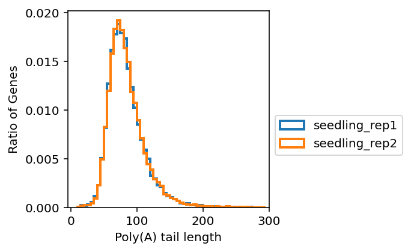

```python
plot_hist_samples_median_polya_length(samples = ["seedling_rep1", "seedling_rep2"],
                                      figsize=[3, 3])
```

## 4.3 Plot heatmap read length distribution

```python
def plot_heatmap_read_length(x,
                             bin_length=1,
                            min_length=10,
                            max_length=200,
                            cmap = "Blues", #Oranges
                            vmin=0,
                            vmax=None,
                            plot_legend=True):

    tmp_bins = range(1, max_length+1, 1)
    x = x[(x>=min_length)]
    total_count = len(x)
    x = x[x<max_length]
    x = pd.Series(np.digitize(x, tmp_bins)).value_counts().sort_index()
    d = pd.DataFrame(x)
    d.columns = ["count"]
    d["length"] = d.index
    d = pd.DataFrame({"length": range(np.digitize(min_length, tmp_bins),
                                      np.digitize(max_length-1, tmp_bins)+1,
                                      1)}).merge(d, on="length", how="left").fillna(0)
    d.index = d["length"]
    d["count"] = d["count"]/total_count
    h = sns.clustermap(d["count"], row_cluster=False, col_cluster=False, cmap=cmap, figsize=[1, 2], vmin=vmin, vmax=vmax)
    h.ax_heatmap.tick_params(right=False, bottom=False, labelright=False, labelbottom=False)
    #h.ax_heatmap.tick_params(bottom=False, labelbottom=False)
    h.ax_heatmap.set_xlabel("")
    h.ax_heatmap.set_ylabel("")
    if not plot_legend:
        h.cax.set_visible(False)
```

```python
plot_heatmap_read_length(seedling_rep1.polya_length,
                        bin_length=1,
                        plot_legend=False)
```

[output not shown]

## 4.4 Plot heatmap median polya length distribution

```python
def plot_heatmap_median_or_mean_polya_length(df,
                                   splice_type="all",
                                   mean_or_median_type = "median",
                                   min_count=20,
                                   bin_length = 5,
                                   cmap="Oranges",
                                   *args,
                                   **kwargs):
    # splice_type: ["all", "ir", "spliced"]
    # mean_or_median_type: ["median", "mean"]
    # used plot_hist_samples_polya_length function
    # other parameters are transforted to plot_hist_samples_polya_length

    polya_length_column = f"{splice_type}_{mean_or_median_type}_polya"
    read_number_column = f"{splice_type}_n_read"

    x = df[polya_length_column][df[read_number_column] >= min_count]
    plot_heatmap_read_length(x,
                             bin_length=bin_length,
                             cmap=cmap,
                             *args, **kwargs)
```

```python
plot_heatmap_median_or_mean_polya_length(sample2polya_length["seedling_rep1"],
                                        splice_type="all",
                                        mean_or_median_type="median",
                                        min_count=20,
                                        bin_length=5,
                                        plot_legend=False)
```

[output not shown]

# 5. Fig 2a,b,c,d nuclear Vs total

## 5.1 Fig 2a nuclear vs total hist

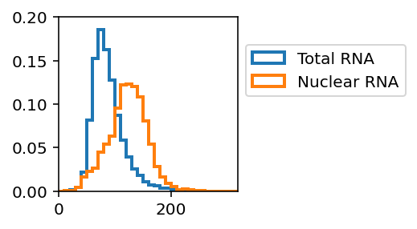

```python
d = sample2polya_length["seedling"].merge(sample2polya_length["ath_nuc"], on="mRNA")
d = d.query('(all_n_read_x >= 20) & (all_n_read_y >= 20)')
fig, ax = plt.subplots(figsize=[2, 2])

x = d.all_median_polya_x
h = plt.hist(x[x<300], bins=range(0, 500, 10),
             weights = np.repeat(1/len(x), (x<300).sum()),
             #density=True,
             histtype="step", lw=2,
             label="Total RNA")

x = d.all_median_polya_y
h = plt.hist(x[x<300], bins=range(0, 500, 10),
             #density=True,
             weights = np.repeat(1/len(x), (x<300).sum()),
             histtype="step", lw=2,
             label="Nuclear RNA")

plt.xlim([0, 320])
plt.ylim([0, 0.2])

plt.legend(loc='lower left', bbox_to_anchor=[1, 0.5])
```

## 5.2 Fig 2b nuclear total ir spliced hist

```
431
```

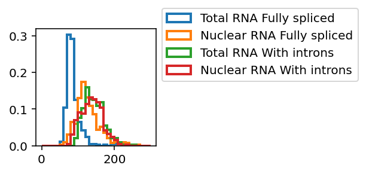

```python
d = sample2polya_length["seedling"].merge(sample2polya_length["ath_nuc"], on="mRNA")
d = d.query('(all_n_read_x >= 20) & (all_n_read_y >= 20)')

d = d.query('(spliced_n_read_x >= 20) & (spliced_n_read_y >= 20) & (ir_n_read_x >= 20) & (ir_n_read_y >= 20)')
print(len(d))
fig, ax = plt.subplots(figsize=[1.8, 1.8])
x = d.spliced_mean_polya_x
h = plt.hist(x, bins=30, range=[0, 300],
             weights = np.repeat(1/len(x), len(x)),
             label="Total RNA Fully spliced",
             histtype="step", lw=2)

x = d.spliced_mean_polya_y
h = plt.hist(x, bins=30, range=[0, 300],
             weights = np.repeat(1/len(x), len(x)),
             label="Nuclear RNA Fully spliced",
             histtype="step", lw=2)

x = d.ir_mean_polya_x
h = plt.hist(x, bins=30, range=[0, 300],
            weights = np.repeat(1/len(x), len(x)),
            label="Total RNA With introns",
            histtype="step", lw=2)

x = d.ir_mean_polya_y
h = plt.hist(x, bins=30, range=[0, 300],
            weights = np.repeat(1/len(x), len(x)),
             label="Nuclear RNA With introns",
             histtype="step", lw=2)

plt.ylim([0, 0.32])
plt.legend(loc='lower left', bbox_to_anchor=[1, 0.5])
```

## 5.3 Fig. 2c & 2d point plot

```python
def plot_two_sample_mRNA_polya(sample1, sample2, splice_type="all", splice_type2=None, min_count=20, color="red",
                               plot_density=True, figsize=None, max_length=300, vmax=None,
                               is_mean=False,
                               plot_color_bar=True,
                              return_x_y=False):
    # require sample2data
    if splice_type2 is None:
        splice_type2 = splice_type
    if is_mean:
        poly_suff = "_mean_polya"
    else:
        poly_suff = "_median_polya"
    n_name1 = splice_type + "_n_read"
    l_name1 = splice_type + poly_suff
    n_name2 = splice_type2 + "_n_read"
    l_name2 = splice_type2 + poly_suff
    df1 = sample2polya_length[sample1]
    df2 = sample2polya_length[sample2]
    df = pd.merge(
        df1.loc[((df1[n_name1] >= min_count) & (df1[l_name1] <= max_length))],
        df2.loc[((df2[n_name2] >= min_count) & (df2[l_name2] <= max_length))],
        on="mRNA",
    )
    print(min_count)
    print(len(df))
    # df = pd.merge(sample2data[sample1].query('(all_n_read >= 20) & (all_median_polya <= 300)'),
    #           sample2data[sample2].query('all_n_read >= 20  & (all_median_polya <= 300)'), on="mRNA")
    fig, ax = plt.subplots(figsize=figsize)
    x = df[l_name1 + "_x"]
    y = df[l_name2 + "_y"]
    if plot_density:
        xy = np.vstack([x, y])
        color = gaussian_kde(xy)(xy)
        plt.scatter(
            x,
            y,
            s=0.5,
            c=color,
            cmap="RdYlBu_r",#plt.cm.gist_earth_r,
            vmin = 0,
            vmax=vmax,
        )
    else:
        plt.scatter(
            x,
            y,
            s=0.5,
            c=color,
        )
    #注意，需要先设scaled，再设xlim和ylim
    plt.axis("scaled")
    plt.xlim(0, max_length)
    plt.ylim(0, max_length)
    plt.plot([0, max_length], [0, max_length], color="black", ls="--", zorder=-10)
    plt.xlabel(sample1 + " " + splice_type)
    plt.ylabel(sample2 + " " + splice_type2)
    r, p = pearsonr(x, y)
    print("pearsonr pavlue:", p)
    print("pearsonr r:", r)
    if plot_density and plot_color_bar:
        colorbar = plt.colorbar()
        colorbar.set_label("Density")
    if return_x_y:
        return (x, y)
```

```
20
1698
pearsonr pavlue: 6.539653134133559e-87
pearsonr r: 0.4535437971114775
```

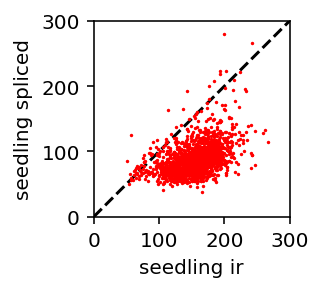

```python
plot_two_sample_mRNA_polya("seedling", "seedling", min_count=20,
                           splice_type="ir",
                           splice_type2="spliced", color="red",
                           plot_density=False, figsize=[3, 1.8])
```

```
20
907
pearsonr pavlue: 2.2084081866804585e-245
pearsonr r: 0.8425175146105017
```

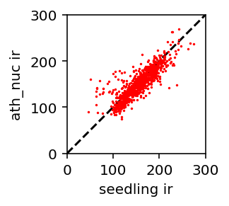

```python
plot_two_sample_mRNA_polya("seedling", "ath_nuc", min_count=20,
                           splice_type="ir",
                           splice_type2="ir", color="red",
                           plot_density=False, figsize=[3, 1.8])
```

# 6. Minior VS Major isoform

```python
select_species = "ath" #ath, rice, soybean, maize
```

```python
alternative_spliced_isoform_dir = os.path.join(data_dir, "alternative_spliced_isoform")
```

```python
file_alternative_spliced_isoform_stat = os.path.join(alternative_spliced_isoform_dir, select_species, "isoform_polya_length_stat.txt")
```

```python
file_alternative_spliced_isoform_bed = os.path.join(alternative_spliced_isoform_dir, select_species, "isoform.bed")
```

```python
file_alternative_spliced_isoform_info = os.path.join(alternative_spliced_isoform_dir, select_species, "isoform.info.txt")
```

## 6.1 Fig 2e point plot

```python
isoform_polya_length_stat = pd.read_csv(file_alternative_spliced_isoform_stat, sep="\t")
```

```
0.0    647
1.0    197
2.0     22
Name: diff, dtype: int64
```

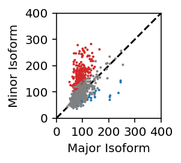

```python
color1 = "#ef5f72" # 红
color2 = "#fcb847" # 黄
color3 = "#782f9a" # 紫
color4 = "#3183bd" # 蓝

colors = isoform_polya_length_stat["diff"].map({0: "grey", 1: default_pal[3], 2: default_pal[0]})
x = isoform_polya_length_stat.major_median_polya_length
y = isoform_polya_length_stat.minor_median_polya_length

print(isoform_polya_length_stat["diff"].value_counts())
fig, ax = plt.subplots(figsize=[1.6, 1.6])
plt.plot([0, 400], [0, 400], color="black", ls="--", zorder=-1)

h = plt.scatter(x, y, marker='o', s=1, color=colors, alpha=1)
plt.axis("scaled")
plt.xlim([0, 400])
plt.ylim([0, 400])
h = plt.xticks([0, 100, 200, 300, 400])
h = plt.yticks([0, 100, 200, 300, 400])
plt.xlabel("Major Isoform")
plt.ylabel("Minor Isoform")
```

## 6.2 Fig S15 buIGV plot

### 6.2.1 Prepare bugv package and input files

Require bugv package developed by jiajinbu. You must put bugv directory in the same directory, or put it in the python module search path.

Require pysam, matplotlib, mpl_toolkits, numpy, pandas, time, pkgutil, importlib,

You can install them use pip, like `pip install pysam`.

```python
import bugv
import pysam
```

Download these bam files and put them in origin_bam_dir.

The file seedling.bam is merge from seedling_rep1.bam and seedling_rep2.bam:

```
samtools merge seedling.bam seedling_rep1.bam seedling_rep2.bam
samtools index seedling.bam
```

```python
origin_bam_dir = os.path.join(data_dir, "bam")
tmp_gene_bam_dir = os.path.join(data_dir, "tmp_gene_bam")
```

```python
if select_species == "ath":
    origin_file_bam = os.path.join(origin_bam_dir, "seedling.bam")
    file_wt_bam = os.path.join(origin_bam_dir, "wt.bam")
    file_upf1upf3_bam = os.path.join(origin_bam_dir, "upf1upf3.bam")
    plot_upf_flag = True
else:
    origin_file_bam = os.path.join(origin_bam_dir, f"{select_species}.bam")
    plot_upf_flag = False
```

### 6.2.2 read data

```python
def read_alternative_spliced_info(filein):

    def split_intron_str(intron_str):
        introns = []
        for intron in intron_str.split(","):
            s, e = intron.split("-")
            introns.append((int(s), int(e)))
        return set(introns)

    gene2isoforms = collections.defaultdict(list)
    with open(filein) as f:
        next(f)
        for l in f:
            gene, isoform_index, isoform_name, select_intron_str, not_contain_intron_str, annoted_represent_mRNA = l.rstrip("\n").split("\t")
            isoform_index = int(isoform_index)
            select_intron_set = split_intron_str(select_intron_str)
            not_contain_intron_set = split_intron_str(not_contain_intron_str)
            gene2isoforms[gene].append([isoform_index, isoform_name,
                                    select_intron_set, not_contain_intron_set, annoted_represent_mRNA])
    for gene, d in gene2isoforms.items():
        d.sort(key=lambda x: x[0])
    return gene2isoforms
```

```python
def read_bed_gene_pos(bed_file):
    gene2pos = {}
    for l in open(bed_file):
        d = l.rstrip("\n").split("\t")
        chr_name, start, end, mRNA, na, strand = d[:6]
        start, end = int(start), int(end)
        start = start - 1
        gene = mRNA.split(".")[0]
        if gene in gene2pos:
            gene2pos[gene][1] = min(gene2pos[gene][1], start)
            gene2pos[gene][2] = max(gene2pos[gene][2], end)
        else:
            gene2pos[gene] = [chr_name, start, end, strand]
    return gene2pos
```

```python
gene2isoforms = read_alternative_spliced_info(file_alternative_spliced_isoform_info)
```

```python
gene2pos = read_bed_gene_pos(file_alternative_spliced_isoform_bed)
```

### 6.2.3 select plot gene

```python
gene = "AT3G01480"
```

All gene ids is sotored in gene2pos.keys()

### 6.2.4 prepare bam of this gene

```python
def select_read_bam(filein_bam, select_read_ids, fileout_bam, not_ir=True):
    inbam = pysam.AlignmentFile(filein_bam, 'rb')
    outbam = pysam.AlignmentFile(fileout_bam, 'wb', template=inbam)
    for read in inbam:
        if read.query_name not in select_read_ids:
            continue
        if not_ir and read.get_tag("ir"):
            continue
        outbam.write(read)
    inbam.close()
    outbam.close()
    pysam.index(fileout_bam)
```

```python
def get_read_blocks(read):

    """
    Input: read objects generated by pysam.
    Output: a list of mapped blocks (genome position, 1-based) of read.
         Each element is a list, [start, end].
         Don't care small InDel and mismatches.
         Sorted by genome position.
    """
    #don't use read.get_blocks
    #insert also seprate block
    #bam_obj.find_introns !!!
    blocks = []
    start = read.reference_start + 1
    end = start - 1
    for (flag, length) in read.cigartuples:
        if flag == 4 or flag == 5 or flag == 1: continue
        if flag == 0 or flag == 2:
            end += length
        if flag == 3:
            blocks.append([start, end])
            start = end + length + 1
            end = start - 1
    blocks.append([start, end])
    return blocks

def get_introns(blocks):
    introns = []
    for i, (start, end) in enumerate(blocks[1:]):
        introns.append((blocks[i][1] + 1, start - 1))
    introns = tuple(introns)
    return introns
```

```python
def select_intron_polya_bam(filein_bam, fileout_bam, max_start=None, min_end=None, select_intron_set={(189628, 189740)}, not_select_intron_set=None, gene_pos=None, mRNA=None): #189627
    inbam = pysam.AlignmentFile(filein_bam, 'rb')
    outbam = pysam.AlignmentFile(fileout_bam, 'wb', template=inbam)
    for read in inbam.fetch(*gene_pos[:3]):
        if read.get_tag('mi') != mRNA:
            continue
        if max_start is not None:
            if read.reference_start + 1 > max_start:
                continue
        if min_end is not None:
            if read.reference_end < min_end:
                continue
        if read.get_tag("pa") < 10:
            continue
        if read.get_tag("ir"):
            continue
        introns = set(get_introns(get_read_blocks(read)))
        if select_intron_set is not None:
            if select_intron_set - introns:
                continue
        if not_select_intron_set is not None:
            if introns & not_select_intron_set:
                continue
        outbam.write(read)
    inbam.close()
    outbam.close()
    pysam.index(fileout_bam)
```

```python
def select_ir_polya_bam(filein_bam, fileout_bam, max_start=None, min_end=None, gene_pos=None, mRNA=None):
    inbam = pysam.AlignmentFile(filein_bam, 'rb')
    outbam = pysam.AlignmentFile(fileout_bam, 'wb', template=inbam)
    for read in inbam.fetch(*gene_pos[:3]):
        if read.get_tag('mi') != mRNA:
            continue
        if max_start is not None:
            if read.reference_start + 1 > max_start:
                continue
        if min_end is not None:
            if read.reference_end < min_end:
                continue
        if read.get_tag("pa") < 10:
            continue
        if not read.get_tag("ir"):
            continue
        outbam.write(read)
    inbam.close()
    outbam.close()
    pysam.index(fileout_bam)
```

```python
isoforms = gene2isoforms[gene]
isoforms
```

```
[[0, 'AT3G01480.1', {(189628, 189740)}, {(189628, 189712)}, 'AT3G01480.1'],
 [1,
  'AT3G01480.isoform2',
  {(189628, 189712)},
  {(189628, 189740)},
  'AT3G01480.1']]
```

```python
gene_pos = gene2pos[gene]
gene_pos
```

```
['chr3', 188319, 190892, '+']
```

```python
tmp_gene_bam_dir = os.path.join(data_dir, "tmp_gene_bam")
```

If you don't download original bam and merge them to seelding.bam. You can skip this cell below, and run

```
file_ir_bam = './tmp_gene_bam/AT3G01480.ir.bam'
isoform_filebams = ['./tmp_gene_bam/AT3G01480.1.bam', './tmp_gene_bam/AT3G01480.isoform2.bam']
plot_upf_flag = False #if you don't download wt.bam and upf1upf3.bam
```

```python
#If you have donwload original bam and plot other gene (Not AT3G01480), please set this
#not_download_original_bam_plot_example = False
not_download_original_bam_plot_example = True

if not not_download_original_bam_plot_example:
    isoform_filebams = []

    for i, isoform_name, select_intron_set, not_select_intron_set, annoted_represent_mRNA in isoforms:
        fileout = os.path.join(tmp_gene_bam_dir, f"{isoform_name}.bam")
        select_intron_polya_bam(origin_file_bam,
                            fileout,
                            max_start=None,
                            min_end=None,
                            select_intron_set=select_intron_set,
                            not_select_intron_set=not_select_intron_set,
                            gene_pos=gene_pos,
                            mRNA=annoted_represent_mRNA)
        isoform_filebams.append(fileout)

    file_ir_bam = os.path.join(tmp_gene_bam_dir, f"{gene}.ir.bam")
    select_ir_polya_bam(origin_file_bam,
                        file_ir_bam,
                        max_start=None,
                        min_end=None,
                        gene_pos=gene_pos,
                        mRNA=annoted_represent_mRNA)
else:
    file_ir_bam = './tmp_gene_bam/AT3G01480.ir.bam'
    isoform_filebams = ['./tmp_gene_bam/AT3G01480.1.bam', './tmp_gene_bam/AT3G01480.isoform2.bam']
    plot_upf_flag = False
```

```python
isoform1_name = isoforms[0][1]
isoform2_name = isoforms[1][1]
annoted_represent_mRNA = isoforms[0][-1]
```

### 6.2.5 plot IGV

```python
def generate_bed_config(color="#3183bd", track_heigth=2, **kwargs):
    bed_config = {"track_height": track_heigth,
                  "keep_select_features": True,
                  "max_cache_obj_number": 1,
              "feature_plot":
                  {   "up_arrow.arrow_color": color,
                      "exon": {
                          "facecolor" : color,
                          "edgecolor" : color,
                      },
                      "5UTR": {
                          "facecolor" : color,
                          "edgecolor" : color,
                      },
                      "3UTR": {
                          "facecolor" : color,
                          "edgecolor" : color,
                      },
                      "CDS": {
                          "facecolor" : color,
                          "edgecolor" : color,
                      },
                      "intron": {
                          "facecolor" : color,
                          "edgecolor" : color,
                      },
                  }
             }
    for k, v in kwargs.items():
        bed_config[k] = v
    return bed_config

def generate_long_read_config(color="#3183bd", track_height=3, select_read_types="polya"):
    if select_read_types == "polya_contain_5lost":
        select_read_types = ["polya_3_not_in_last_exon", "polya_5lost", "polya"]
    config={
            "track_height": 3,
            "feature_plot.feature_space": 0,
            "feature_plot.select_read_types": select_read_types, #["polya_3_not_in_last_exon", "polya_5lost", "polya"], #["polya"], #
            "feature_plot.read_type_order": [[["elongating", "splicing_intermediate", "elongating_3_mapping_low_accuracy","elongating_5lost" ], "elongating"],
                                             [["polya_3_not_in_last_exon", "polya_5lost", "polya"], "polya"],
                                            ],
            "feature_plot.read_type_sort_method": {"polya": "end"},
            "feature_plot.polyA.plot_show": True,
            "feature_plot.exon.facecolor": color,
            "feature_plot.exon.edgecolor": color,
           }
    return config

def generate_rnasashimiplot_config(color='#984EA3'):
    config={
        "track_height": 3,
        "read_specific_strand": False,
        "rnasashimiplot": {
            "all_color": color,
            "min_junction_ratio": 0.1,
            "max_junction_line_width": 0.4,
             "line_width_based_on_count": True,
        }

    }
    return config
```

```python
def print_describe(gene, gene_pos, isoforms):
    chr_name, gene_start, gene_end, strand = gene_pos

    print_str = (
        f"Print {gene}\n"
        "\n"
        "\n"
        f"The position of {gene} is:\n"
        f"\tchr_name:\t{chr_name}\n"
        f"\tgene_start:\t{gene_start}\n"
        f"\tgene_end:\t{gene_end}\n"
        f"\tstrand:\t\t{strand}\n"
        "\n"
        "The x axis in the plot indicate the position of the gene.\n"
        f"0 in x axis represent the strat position of gene: {gene_start} in genome.\n"
    )

    print_str += "The alternative spliced introns: \n\n"
    for i, isoform in enumerate(isoforms):
        if i == 0:
            major_or_minior = "major"
        else:
            major_or_minior = "minor"
        isoform_name = isoform[1]
        j = i + 1
        print_str += f"The {j} isoform structure and full length track is:\n"
        print_str += f"\tThe {major_or_minior} isoform {isoform_name}: \n"
        print_str += "\t\tintron_start_in_x_axis\tintron_end_in_x_aixs\n"
        for intron_start, intron_end in isoform[2]:
            if strand == "+":
                intron_start -= gene_start
                intron_end -= gene_start
            else:
                intron_start = gene_end - intron_start
                intron_end = gene_end - intron_end
            print_str += f"\t\t{intron_start}\t\t\t{intron_end}\n"
    j = j + 1
    print_str += f"The {j} full length track is transcripts with introns.\n"

    print(print_str)
```

```python
#蓝, 紫，黄，红, 棕黄
colors = ["#3183bd", "#782f9a", "#fcb847",  "#ef5f72", '#FF7F00']
```

```python
select_read_types = ["polya", "polya_3_not_in_last_exon", "polya_5lost"]

bed_file = file_alternative_spliced_isoform_bed

bgv = bugv.BuGV()

bgv.add_track("RulerTrack", config={"track_height": 1, "ruler.ruler_length": 200})

for i, isoform in enumerate(isoforms):
    j = i % 5
    isoform_name = isoforms[i][1]
    config=generate_bed_config(color=colors[j],
                                     track_heigth=1)
    config["select_features"] = [isoform_name]
    bgv.add_track("BedTrack",
                  file_name=bed_file,
                  config=config
                  )

for i, filebam in enumerate(isoform_filebams):
    j = i % 5
    isoform_name = isoforms[i][1]
    config = generate_long_read_config(color=colors[j],
                                       track_height=3,
                                       select_read_types=select_read_types)
    bgv.add_track(
            "FulllengthBamTrack",
            file_name=filebam,
            track_name=isoform_name,
            config=config
        )

bgv.add_track(
        "FulllengthBamTrack",
        file_name=file_ir_bam,
        track_name="ir",
        config=generate_long_read_config(color=colors[2], track_height=3, select_read_types=select_read_types)
    )

if plot_upf_flag:
    #if you don't want to plot wt bam, delete this
    bgv.add_track(
        "RNASashimiplot",
        file_name=file_wt_bam,
        track_name="wt",
        config=generate_rnasashimiplot_config(colors[3]),
    )

    #if you don't want to plot upf1upf3 bam, delete this
    bgv.add_track(
        "RNASashimiplot",
        file_name=file_upf1upf3_bam,
        track_name="wt",
        config=generate_rnasashimiplot_config(colors[4]),
    )

bgv.add_track("XaxisGeneTrack", config={"track_height": 2})
```

```
<bugv.tracks.xaxistrack.XaxisGeneTrack at 0x2b24b6fa5e50>
```

```
Print AT3G01480


The position of AT3G01480 is:
	chr_name:	chr3
	gene_start:	188319
	gene_end:	190892
	strand:		+

The x axis in the plot indicate the position of the gene.
0 in x axis represent the strat position of gene: 188319 in genome.
The alternative spliced introns:

The 1 isoform structure and full length track is:
	The major isoform AT3G01480.1:
		intron_start_in_x_axis	intron_end_in_x_aixs
		1309			1421
The 2 isoform structure and full length track is:
	The minor isoform AT3G01480.isoform2:
		intron_start_in_x_axis	intron_end_in_x_aixs
		1309			1393
The 3 full length track is transcripts with introns.

188320.5 188370.5 -0.5750000000000001 -0.38
188320.5 188370.5 -0.5750000000000001 -0.38
```

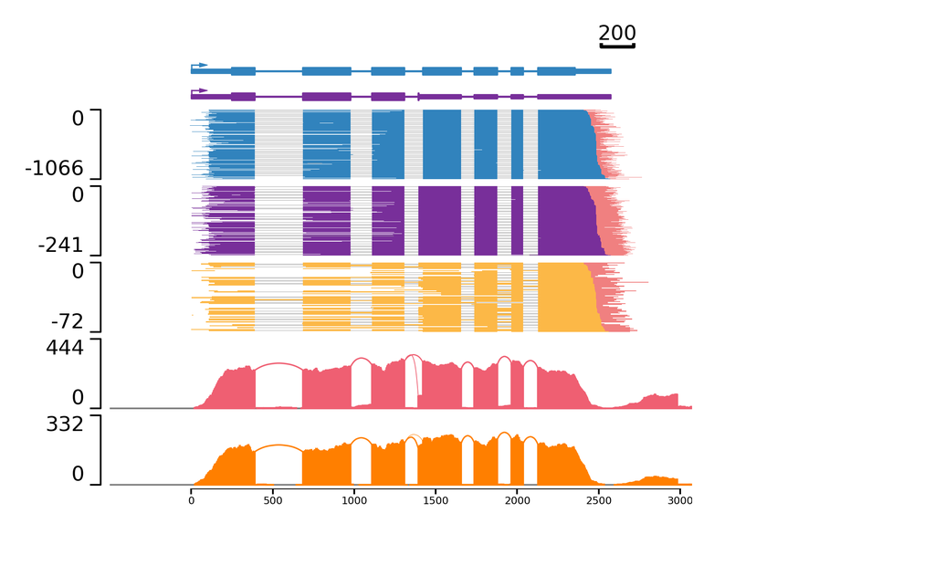

```python
#Track1: rule
#Track2: major isoform
#Track3: minor isoform
#Track4: FLEP-seq major isoform  (Blue)
#Track5: FLEP-seq minor isoform  (Purple)
#Track6: FLEP-seq transcripts with introns (Yellow)
#Track7: wt RNA-seq bam
#Track8: upf1upf3 RNA-seq bam
#Note: the right side of covereage showed in wt and upf1upf3 RNA-seq bam track is derived from another gene.
print_describe(gene, gene_pos, isoforms)

bgv.plot_mRNA(annoted_represent_mRNA)
#plt.savefig("/public/home/jiajb/self/test/b.pdf")
plt.show()
```

```
Print AT3G01480


The position of AT3G01480 is:
	chr_name:	chr3
	gene_start:	188319
	gene_end:	190892
	strand:		+

The x axis in the plot indicate the position of the gene.
0 in x axis represent the strat position of gene: 188319 in genome.
The alternative spliced introns:

The 1 isoform structure and full length track is:
	The major isoform AT3G01480.1:
		intron_start_in_x_axis	intron_end_in_x_aixs
		1309			1421
The 2 isoform structure and full length track is:
	The minor isoform AT3G01480.isoform2:
		intron_start_in_x_axis	intron_end_in_x_aixs
		1309			1393
The 3 full length track is transcripts with introns.

188320.5 188370.5 -0.5750000000000001 -0.38
188320.5 188370.5 -0.5750000000000001 -0.38
```

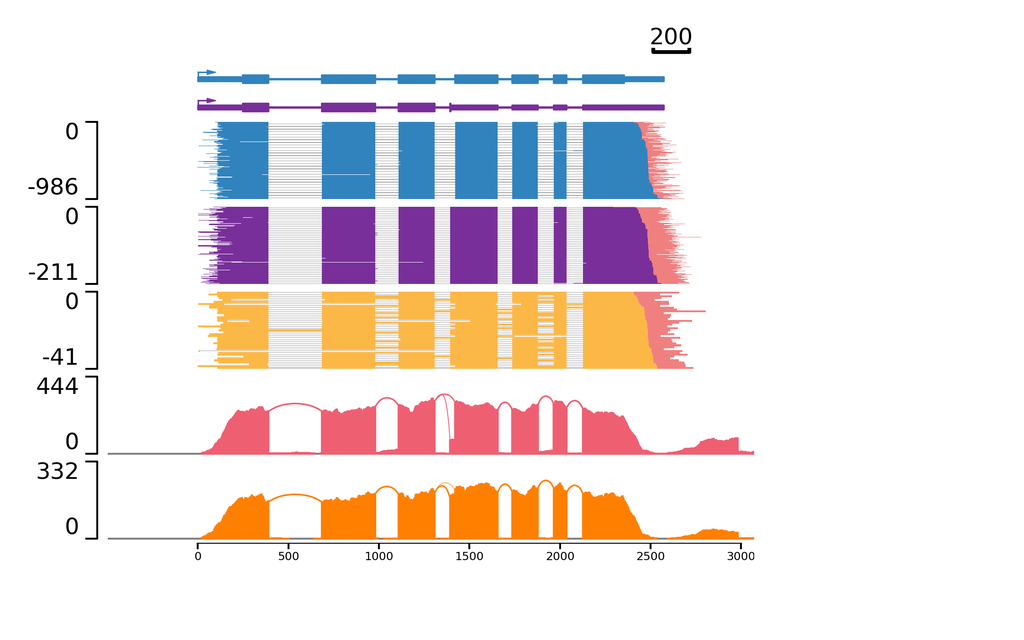

```python
#Only show full-length transcripts
select_read_types = ["polya"]
bgv.load_track_config({"feature_plot.select_read_types": select_read_types})

#Track1: rule
#Track2: major isoform
#Track3: minor isoform
#Track4: FLEP-seq major isoform  (Blue)
#Track5: FLEP-seq minor isoform  (Purple)
#Track6: FLEP-seq transcripts with introns (Yellow)
#Track7: wt RNA-seq bam
#Track8: upf1upf3 RNA-seq bam
#Note: the right side of covereage showed in wt and upf1upf3 RNA-seq bam track is derived from another gene.
print_describe(gene, gene_pos, isoforms)
bgv.plot_mRNA(annoted_represent_mRNA)
#plt.savefig("/public/home/jiajb/self/test/b.pdf")
plt.show()
```

```
188320.5 188370.5 -0.5750000000000001 -0.38
188320.5 188370.5 -0.5750000000000001 -0.38
```

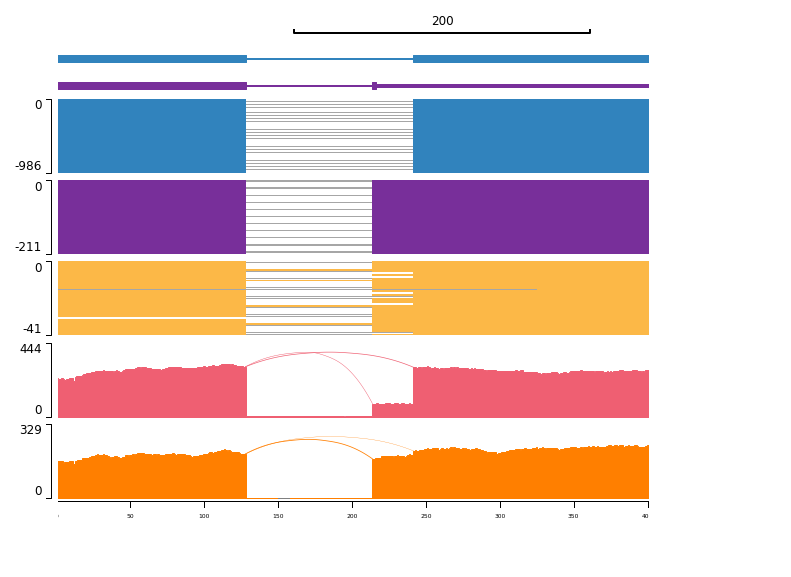

```python
#Zoom in and only show the alternatived spliced introns
#Track1: rule
#Track2: major isoform
#Track3: minor isoform
#Track4: FLEP-seq major isoform  (Blue)
#Track5: FLEP-seq minor isoform  (Purple)
#Track6: FLEP-seq transcripts with introns (Yellow)
#Track7: wt RNA-seq bam
#Track8: upf1upf3 RNA-seq bam
bgv.plot(region=["chr3", 189500, 189900, "+"])
plt.show()
```

Note: the right side of covereage showed in wt and upf1upf3 RNA-seq bam track is derived from another gene (AT3G01490).

We can plot the original alignment in the region of AT3G01480 (left) and AT3G01490 (right):

```python
origin_bed_dir = os.path.join(data_dir, "genome_bed")
bed_file = os.path.join(origin_bed_dir, "ath.bed")
bam_file = os.path.join(origin_bam_dir, "seedling.bam")
select_read_types = ["polya"]

bgv_all_gene = bugv.BuGV()

bgv_all_gene.add_track("RulerTrack", config={"track_height": 1, "ruler.ruler_length": 200})

bgv_all_gene.add_track("BedTrack",
              file_name=bed_file,
              config=generate_bed_config(color="black",
                                 track_heigth=1)
              )

bgv_all_gene.add_track(
        "FulllengthBamTrack",
        file_name=bam_file,
        config=generate_long_read_config(color=colors[0],
                                   track_height=3,
                                   select_read_types=select_read_types)
    )

bgv_all_gene.add_track(
        "RNASashimiplot",
        file_name=file_wt_bam,
        track_name="wt",
        config=generate_rnasashimiplot_config(colors[3]),
    )

bgv_all_gene.add_track(
        "RNABamAlignTrack",
        file_name=file_wt_bam,
        track_name="wt",
        config={"track_height":10},
    )

bgv_all_gene.add_track("XaxisGeneTrack", config={"track_height": 2})
```

```
<bugv.tracks.xaxistrack.XaxisGeneTrack at 0x2af3da36d390>
```

```
188320.5 188370.5 -0.5750000000000001 -0.38
193721.5 193671.5 -1.5750000000000002 -1.38
```

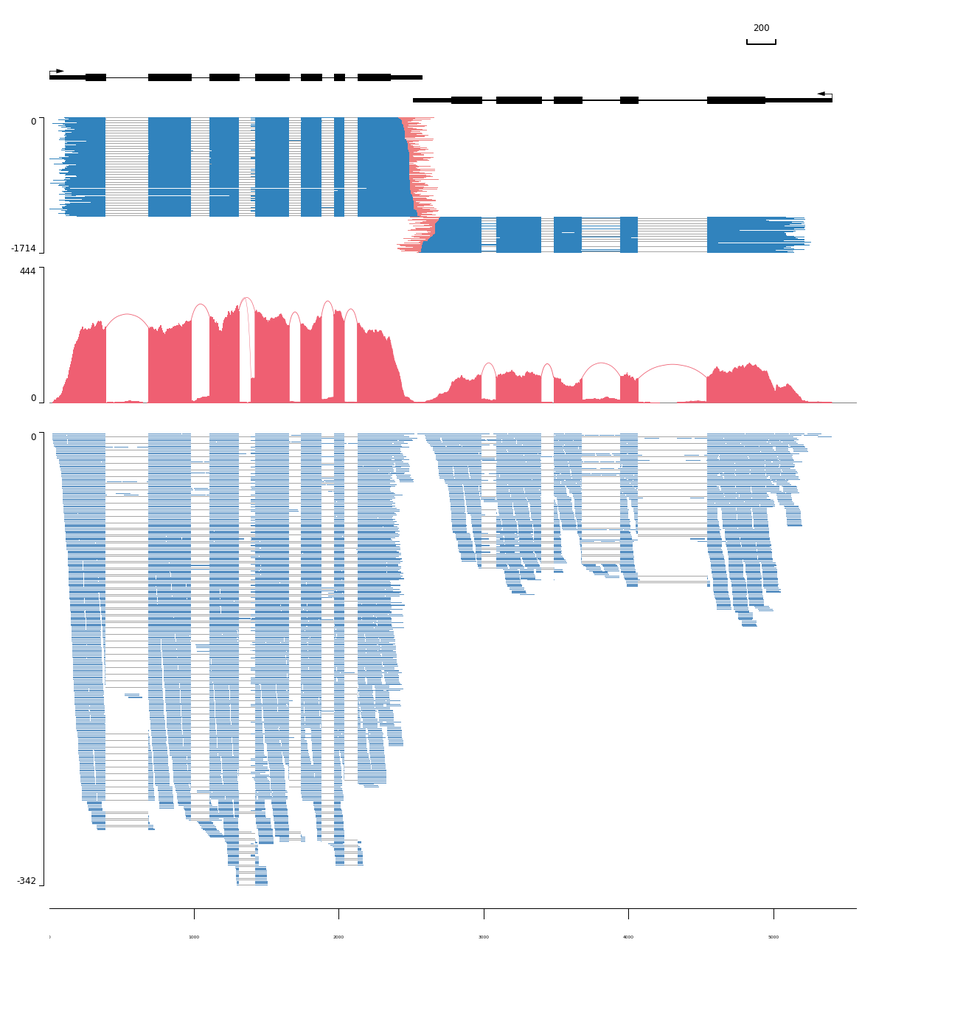

```python
#track1: rule
#track2: gene bed AT3G01480 (left) and AT3G01490 (right)
#track3: FLEP-seq seedling
#track4: coverage wt RNA-seq bam
#track5: alignment wt RNA-seq bam
bgv_all_gene.plot(region=['chr3', 188319, 193892, "+"], figsize=[10, 10])
```

### 6.2.6 plot polya_length

```python
dfs = []
for i in range(len(isoforms)+1):
    if i == len(isoforms):
        isoform_name = "ir"
    else:
        isoform_name = isoforms[i][1]
    polya_length = bgv.tracks[i+len(isoforms)+1].region_data.df.polya_length.values
    df = pd.DataFrame({"polya_length": polya_length})
    df["sample"] = isoform_name
    dfs.append(df)
dfs = pd.concat(dfs)
```

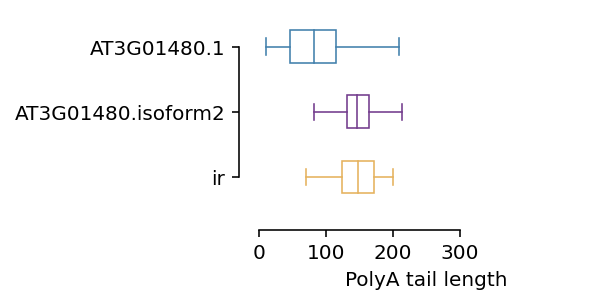

```python
fig, ax = plt.subplots(figsize=[3, 1.8])
sns.boxplot(data=dfs, x="polya_length", y="sample",
            palette=colors[:3],
            ax=ax,
            showfliers=False, width=0.5, linewidth=0.8)

for i, artist in enumerate(ax.artists):
    # Set the linecolor on the artist to the facecolor, and set the facecolor to None
    col = artist.get_facecolor()
    artist.set_edgecolor(col)
    artist.set_facecolor('None')

    # Each box has 6 associated Line2D objects (to make the whiskers, fliers, etc.)
    # Loop over them here, and use the same colour as above
    for j in range(i*5,i*5+5):
        line = ax.lines[j]
        line.set_color(col)
        line.set_mfc(col)
        line.set_mec(col)

plt.xlim(0, 500)
plt.xticks([0, 100, 200, 300])
sns.despine(offset=10, trim=True)
plt.ylabel("")
plt.xlabel("PolyA tail length")
plt.show()
```

# 7. Fig 3a Gene distriubtion heatmap

```python
def generate_polya_bin(df):
    #min_polya_length 10
    #min_count 50
    df = df.query('polya_length >= 10')
    cut_bins = list(range(10, 250, 10))
    tmp_length_bin = np.digitize(
        df.polya_length,
        cut_bins,
    )
    polya_bin = pd.crosstab(df.mRNA, tmp_length_bin)
    polya_bin = polya_bin.fillna(0)
    polya_bin = polya_bin.divide(polya_bin.sum(axis=1), axis=0)

    bin_sort_value = polya_bin.apply(lambda x: np.argsort(-x), axis=1)
    bin_sort_value.columns = ["o" + str(i) for i in range(len(polya_bin.columns))]
    bin_sort_value = bin_sort_value.reset_index()
    mRNA_median = df.groupby('mRNA').agg({"polya_length": [len, np.median]})
    mRNA_median = mRNA_median.reset_index()
    mRNA_median.columns = ["mRNA", "count", "median"]
    bin_sort_value = bin_sort_value.merge(mRNA_median, on="mRNA")
    bin_sort_value = bin_sort_value.sort_values(["o0", "median"])

    bin_sort_value = bin_sort_value.query('count >= 50')
    polya_bin = polya_bin.loc[list(bin_sort_value.mRNA), :]
    return (polya_bin, bin_sort_value)
```

```python
def real_plot_polya_clustermap(df, vmax=0.15, figsize=[7, 7]):
    print(len(df))
    cg = sns.clustermap(df,  vmin=0, vmax=vmax,
                    row_cluster=False, col_cluster=False,  method="average",
               cmap="RdYlBu_r", figsize=figsize) # col_linkage=col_linkage, #figsize=[3,3], yticklabels=False
    cg.ax_heatmap.tick_params(right=False, bottom=False, labelright=False, labelbottom=False)
    cg.ax_heatmap.set_xlabel("")
    cg.ax_heatmap.set_ylabel("")
    cg.cax.set_visible(False)
    return cg
```

```python
polya_bin, bin_sort_value = generate_polya_bin(pd.concat([seedling_rep1, seedling_rep2]))
```

```
13116
```

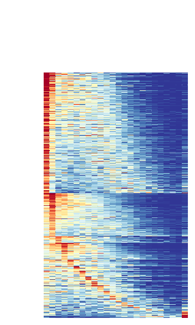

```python
real_plot_polya_clustermap(polya_bin, figsize=[4, 5])
```

# 8. Fig 3b one gene heatmap

```python
def get_one_sample_df(mRNA, df, bin_length=10, max_length=200):
    df1 = df.query('mRNA==@mRNA')
    d1 = pd.DataFrame({"length": range(np.digitize(10, range(1, 500, bin_length)),
         np.digitize(max_length-1, range(1, 500, bin_length))+1, 1)})
    if len(df1) == 0:
        d = d1
        d["count"] = 0
    else:
        x = df1.polya_length
        x = x[(x>=10) & (x<max_length)]
        x = pd.Series(np.digitize(x, range(1, 500, bin_length))).value_counts().sort_index()
        d = pd.DataFrame(x)
        d.columns = ["count"]
        d["length"] = d.index
        d = d1.merge(d, on="length", how="left").fillna(0)
        d.index = d["length"]
        d["count"] = d["count"]/d["count"].sum()
    return d
```

```python
def plot_mRNA_tissues(mRNA, dfs, samples, bin_length=10, figsize=[3, 3]):
    title = mRNA
    result_df = {}
    for df, sample in zip(dfs, samples):
        ratio = get_one_sample_df(mRNA, df, bin_length)["count"].values
        result_df[sample] = ratio
    result_df = pd.DataFrame(result_df).T

    h = sns.clustermap(
        result_df,
        row_cluster=False,
        col_cluster=False,
        cmap="RdYlBu_r",
        figsize=figsize,
        vmin=0, vmax=0.15
    )

    h.ax_heatmap.tick_params(right=False, bottom=False, labelright=True, labelbottom=False)
    h.ax_heatmap.set_xlabel(title)
    h.ax_heatmap.set_ylabel("")
    h.cax.set_visible(False)
```

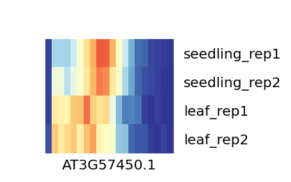

```python
plot_mRNA_tissues("AT3G57450.1",
                 [seedling_rep1, seedling_rep2, leaf_rep1, leaf_rep2],
                 ["seedling_rep1", "seedling_rep2", "leaf_rep1", "leaf_rep2"],
                 figsize=[3, 2])
```

# 9. Homologous genes

```python
def tmp_process(df):

    def remove_unique(df, specie1, specie2):
        s = df[specie1].value_counts()
        f1 = df[specie1].isin(s[s==1].index)
        s = df[specie2].value_counts()
        f2 = df[specie2].isin(s[s==1].index)
        df = df[f1 & f2]
        return df

    get_key = {"ath": "shoot",
           "rice": "rice",
          "maize": "maize",
          "soybean": "soybean"}

    def get_s_data(s):
        d = sample2polya_length[get_key[s]].copy()
        d.columns = [s + "_" + c for c in d.columns]
        return d

    df.drop(columns='Orthogroup', inplace=True)
    select_species = df.columns
    specie1, specie2 = select_species
    for specie in select_species:
        df[specie] = df[specie].str.split(', ')
        df = df.explode(specie)
    df = df.reset_index(drop=True)
    df.drop_duplicates(inplace=True)
    #df = remove_unique(df, specie1, specie2)

    for specie in select_species:
        df = df.merge(get_s_data(specie), left_on=specie, right_on=specie + "_mRNA")
    df = df[(df[f"{specie1}_all_n_read"] >= 50) & (df[f"{specie2}_all_n_read"] >= 50 )]
    #df = remove_unique(df, specie1, specie2)
    return df
```

```python
df_ath_maize = pd.read_csv(os.path.join(homologous_data_dir, "ath__v__maize.tsv"), sep="\t")
df_ath_rice = pd.read_csv(os.path.join(homologous_data_dir, "ath__v__rice.tsv"), sep="\t")
df_ath_soybean = pd.read_csv(os.path.join(homologous_data_dir, "ath__v__soybean.tsv"), sep="\t")
df_rice_maize = pd.read_csv(os.path.join(homologous_data_dir, "rice__v__maize.tsv"), sep="\t")
df_soybean_maize = pd.read_csv(os.path.join(homologous_data_dir, "soybean__v__maize.tsv"), sep="\t")
df_soybean_rice = pd.read_csv(os.path.join(homologous_data_dir, "soybean__v__rice.tsv"), sep="\t")
```

```python
df_ath_maize = tmp_process(df_ath_maize)
df_ath_rice = tmp_process(df_ath_rice)
df_ath_soybean = tmp_process(df_ath_soybean)
df_rice_maize = tmp_process(df_rice_maize)
df_soybean_maize = tmp_process(df_soybean_maize)
df_soybean_rice = tmp_process(df_soybean_rice)
```

```
['ath', 'soybean']
(0.5283524667230047, 0.0)
0.5283524667230047
```

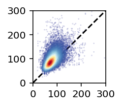

```python
df = df_ath_soybean
specie1, specie2 = df.columns[:2]
if specie1 == "soybean":
    specie1, specie2 = specie2, specie1
vmax=0.00045
figsize = None
plot_colorbar = False
if figsize is None:
    if plot_colorbar:
        figsize = [1.65, 1.65]
    else:
        figsize = [1.36, 1.36]
print([specie1, specie2])
x = df[f"{specie1}_all_median_polya"]
y = df[f"{specie2}_all_median_polya"]
print(pearsonr(x, y))
plot_x_y(x, y, lim=[0, 300], figsize=figsize, vmax=vmax, plot_colorbar=plot_colorbar)
h = plt.xticks([0, 100, 200, 300])
h = plt.yticks([0, 100, 200, 300])
```